# Mini-projet d’analyse multivariée - VigorTerra

# 1 1. Compréhension du problème

Ce mini-projet traite un jeu de données agricole tunisien multidimensionnel. L’objectif est de construire une typologie interprétable à partir d’indicateurs agronomiques, climatiques et pédologiques.

La problématique est la suivante: quels profils de cultures et de contextes agro-climatiques peut-on distinguer, et comment ces profils peuvent-ils aider la prise de décision agricole?

Le jeu de données combine notamment:

- `annee`
- `Item` (culture)
- `surface_cultivee_ha`
- `production_tonnes`
- `rendement_tonnes_ha`
- `pluviometrie_mm`
- `temperature_moyenne_c`
- `humidite_pct`
- `ph`
- `azote_N`
- `phosphore_P_mg_kg`
- `potassium_K_mg_kg`

```r
find_dataset <- function() {
  candidates <- c(
    "DATA/dataset_filtré.csv",
    "DATA/dataset_ml_rendement_tunisie.csv",
    "../DATA/dataset_filtré.csv",
    "../DATA/dataset_ml_rendement_tunisie.csv",
    "agriculture_scraping/data/dataset_ml_rendement_tunisie.csv",
    "../agriculture_scraping/data/dataset_ml_rendement_tunisie.csv"
  )
  found <- candidates[file.exists(candidates)][1]
  if (is.na(found) || length(found) == 0) {
    stop("Aucun fichier dataset_ml_rendement_tunisie.csv ou dataset_filtré.csv n'a été trouvé.")
  }
  found
}

data_path <- find_dataset()
df_raw <- readr::read_csv(data_path, show_col_types = FALSE)

glimpse(df_raw)
```

```
## Rows: 2,182
## Columns: 13
## $ annee                 <dbl> 2010, 2010, 2010, 2010, 2010, 2010, 2010, 2010, …
## $ Item                  <chr> "Almonds, in shell", "Anise, badian, coriander, …
## $ surface_cultivee_ha   <dbl> 162550, 12965, 26294, 5982, 1800, NA, 27, 184700…
## $ production_tonnes     <dbl> 52000.00, 10029.30, 126000.00, 23500.00, 14000.0…
## $ yield_value           <dbl> 319.9, 773.6, 4791.9, 3928.7, 7777.8, NA, 10528.…
## $ rendement_tonnes_ha   <dbl> 0.03199, 0.07736, 0.47919, 0.39287, 0.77778, NA,…
## $ pluviometrie_mm       <dbl> NA, NA, NA, NA, NA, NA, NA, NA, NA, NA, NA, NA, …
## $ temperature_moyenne_c <dbl> NA, NA, NA, NA, NA, NA, NA, NA, NA, NA, NA, NA, …
## $ humidite_pct          <dbl> NA, NA, NA, NA, NA, NA, NA, NA, NA, NA, NA, NA, …
## $ ph                    <dbl> 7.736923, 7.736923, 7.736923, 7.736923, 7.736923…
## $ azote_N               <dbl> 0.1107846, 0.1107846, 0.1107846, 0.1107846, 0.11…
## $ phosphore_P_mg_kg     <dbl> 33.30154, 33.30154, 33.30154, 33.30154, 33.30154…
## $ potassium_K_mg_kg     <dbl> 228.5185, 228.5185, 228.5185, 228.5185, 228.5185…
```

```r
summary(df_raw)
```

```
##      annee             Item      surface_cultivee_ha production_tonnes
##  Min.   :2010   Length   :2182   Min.   :      0     Min.   :      0
##  1st Qu.:2013   N.unique : 148   1st Qu.:   1479     1st Qu.:   1579
##  Median :2017   N.blank  :   0   Median :   6510     Median :  11070
##  Mean   :2017   Min.nchar:   4   Mean   :  87725     Mean   : 148566
##  3rd Qu.:2021   Max.nchar:  76   3rd Qu.:  19307     3rd Qu.:  96910
##  Max.   :2024                    Max.   :3622842     Max.   :3219344
##                                  NAs    :922
##   yield_value       rendement_tonnes_ha pluviometrie_mm temperature_moyenne_c
##  Min.   :    52.7   Min.   : 0.00527    Min.   :242.8   Min.   :19.25
##  1st Qu.:   999.8   1st Qu.: 0.09998    1st Qu.:301.6   1st Qu.:19.43
##  Median :  5097.9   Median : 0.50979    Median :325.0   Median :19.57
##  Mean   :  9949.8   Mean   : 0.99498    Mean   :331.7   Mean   :19.78
##  3rd Qu.: 12289.8   3rd Qu.: 1.22898    3rd Qu.:376.5   3rd Qu.:20.22
##  Max.   :108448.2   Max.   :10.84482    Max.   :422.4   Max.   :20.41
##  NAs    :911        NAs    :911         NAs    :730     NAs    :730
##   humidite_pct         ph           azote_N       phosphore_P_mg_kg
##  Min.   :62.57   Min.   :7.707   Min.   :0.1065   Min.   :33.30
##  1st Qu.:63.38   1st Qu.:7.732   1st Qu.:0.1146   1st Qu.:35.17
##  Median :64.77   Median :7.754   Median :0.1166   Median :37.70
##  Mean   :64.65   Mean   :7.751   Mean   :0.1161   Mean   :36.93
##  3rd Qu.:66.26   3rd Qu.:7.760   3rd Qu.:0.1182   3rd Qu.:38.33
##  Max.   :66.74   Max.   :7.791   Max.   :0.1275   Max.   :40.53
##  NAs    :730     NAs    :126     NAs    :126      NAs    :126
##  potassium_K_mg_kg
##  Min.   :199.4
##  1st Qu.:210.9
##  Median :217.6
##  Mean   :216.9
##  3rd Qu.:224.3
##  Max.   :233.0
##  NAs    :126
```

# 2 2. Préparation des données

Le choix de préparation suit trois règles: conserver la lisibilité agronomique, traiter les valeurs manquantes de façon robuste et homogénéiser les échelles avant les méthodes multivariées.

```r
core_numeric <- c(
  "annee", "surface_cultivee_ha", "production_tonnes", "rendement_tonnes_ha",
  "pluviometrie_mm", "temperature_moyenne_c", "humidite_pct",
  "ph", "azote_N", "phosphore_P_mg_kg", "potassium_K_mg_kg"
)

classify_crop_family <- function(item) {
  item <- str_to_lower(coalesce(as.character(item), ""))
  out <- case_when(
    str_detect(item, "wheat|barley|oats|sorghum|maize|rice|triticale|cereals|dur|tendre|orge") ~ "Cereales",
    str_detect(item, "tomato|potato|onion|garlic|cabbage|lettuce|vegetable|melon|cucumber|pumpkin|spinach|carrot") ~ "Legumes",
    str_detect(item, "apple|pear|grape|orange|lemon|dates|fig|apricot|peach|plum|almond|pistachio|hazelnut|fruit") ~ "Fruits",
    str_detect(item, "olive|cotton|sunflower|sesame|linseed|oil|tobacco|sugar|beet") ~ "Industrie",
    str_detect(item, "pea|bean|lentil|chick|pulse") ~ "Legumineuses",
    TRUE ~ "Autres"
  )
  factor(out, levels = c("Cereales", "Legumineuses", "Legumes", "Fruits", "Industrie", "Autres"))
}

impute_median <- function(x) {
  if (!is.numeric(x)) return(x)
  x[is.na(x)] <- median(x, na.rm = TRUE)
  x
}

cap_iqr <- function(x) {
  if (!is.numeric(x)) return(x)
  q1 <- quantile(x, 0.25, na.rm = TRUE)
  q3 <- quantile(x, 0.75, na.rm = TRUE)
  iqr <- q3 - q1
  lower <- q1 - 1.5 * iqr
  upper <- q3 + 1.5 * iqr
  x <- pmax(x, lower)
  x <- pmin(x, upper)
  x
}
```

```r
df_prep <- df_raw %>%
  mutate(across(any_of(core_numeric), ~ readr::parse_number(as.character(.x)))) %>%
  mutate(
    annee = as.integer(annee),
    famille_culture = classify_crop_family(Item)
  ) %>%
  filter(!is.na(rendement_tonnes_ha)) %>%
  filter(annee >= 2015) %>%
  mutate(across(any_of(core_numeric), impute_median)) %>%
  mutate(across(all_of(setdiff(core_numeric, "annee")), cap_iqr))

missing_before <- df_raw %>% summarise(across(everything(), ~ sum(is.na(.x))))
missing_after <- df_prep %>% summarise(across(everything(), ~ sum(is.na(.x))))

missing_before
```

```
## # A tibble: 1 × 13
##   annee  Item surface_cultivee_ha production_tonnes yield_value
##   <int> <int>               <int>             <int>       <int>
## 1     0     0                 922                 0         911
## # ℹ 8 more variables: rendement_tonnes_ha <int>, pluviometrie_mm <int>,
## #   temperature_moyenne_c <int>, humidite_pct <int>, ph <int>, azote_N <int>,
## #   phosphore_P_mg_kg <int>, potassium_K_mg_kg <int>
```

```r
missing_after
```

```
## # A tibble: 1 × 14
##   annee  Item surface_cultivee_ha production_tonnes yield_value
##   <int> <int>               <int>             <int>       <int>
## 1     0     0                   0                 0           0
## # ℹ 9 more variables: rendement_tonnes_ha <int>, pluviometrie_mm <int>,
## #   temperature_moyenne_c <int>, humidite_pct <int>, ph <int>, azote_N <int>,
## #   phosphore_P_mg_kg <int>, potassium_K_mg_kg <int>, famille_culture <int>
```

```r
df_prep %>%
  summarise(
    n_lignes = n(),
    n_cultures = n_distinct(Item),
    annee_min = min(annee),
    annee_max = max(annee),
    rendement_median = median(rendement_tonnes_ha),
    rendement_sd = sd(rendement_tonnes_ha)
  )
```

```
## # A tibble: 1 × 6
##   n_lignes n_cultures annee_min annee_max rendement_median rendement_sd
##      <int>      <int>     <dbl>     <dbl>            <dbl>        <dbl>
## 1      850         85      2015      2024            0.511        0.975
```

Le traitement retient les observations les plus cohérentes pour une analyse multivariée: le rendement doit être renseigné, et l’étude est recentrée sur la période 2015-2024 où les variables climatiques et pédologiques sont les plus complètes. Les valeurs manquantes restantes sont imputées par la médiane car elle est robuste aux distributions asymétriques. Les outliers sont bornés par la règle de l’IQR pour éviter qu’une poignée de valeurs extrêmes ne déforme l’ACP et la segmentation.

```r
numeric_vars <- c(
  "surface_cultivee_ha", "production_tonnes", "rendement_tonnes_ha",
  "pluviometrie_mm", "temperature_moyenne_c", "humidite_pct",
  "ph", "azote_N", "phosphore_P_mg_kg", "potassium_K_mg_kg"
)

df_model <- df_prep %>%
  select(all_of(numeric_vars), annee, famille_culture, Item)

df_scaled <- df_model %>%
  select(all_of(numeric_vars)) %>%
  scale() %>%
  as.data.frame()

summary(df_scaled)
```

```
##  surface_cultivee_ha production_tonnes rendement_tonnes_ha pluviometrie_mm
##  Min.   :-0.8532     Min.   :-0.8221   Min.   :-0.9130     Min.   :-1.6564
##  1st Qu.:-0.7573     1st Qu.:-0.7832   1st Qu.:-0.8151     1st Qu.:-0.5586
##  Median :-0.4457     Median :-0.5383   Median :-0.3964     Median :-0.1155
##  Mean   : 0.0000     Mean   : 0.0000   Mean   : 0.0000     Mean   : 0.0000
##  3rd Qu.: 0.3844     3rd Qu.: 0.3150   3rd Qu.: 0.5037     3rd Qu.: 0.8395
##  Max.   : 2.0971     Max.   : 1.9623   Max.   : 2.4817     Max.   : 1.6960
##  temperature_moyenne_c  humidite_pct           ph              azote_N
##  Min.   :-1.2784       Min.   :-1.3274   Min.   :-1.82277   Min.   :-1.87164
##  1st Qu.:-0.8574       1st Qu.:-0.8071   1st Qu.:-0.87207   1st Qu.:-0.52354
##  Median :-0.2626       Median :-0.1362   Median : 0.03169   Median :-0.07336
##  Mean   : 0.0000       Mean   : 0.0000   Mean   : 0.00000   Mean   : 0.00000
##  3rd Qu.: 1.0419       3rd Qu.: 1.0379   3rd Qu.: 0.90610   3rd Qu.: 0.54785
##  Max.   : 1.5031       Max.   : 1.3459   Max.   : 1.40493   Max.   : 2.15495
##  phosphore_P_mg_kg potassium_K_mg_kg
##  Min.   :-1.7511   Min.   :-1.99386
##  1st Qu.:-0.3760   1st Qu.:-0.47871
##  Median : 0.1104   Median :-0.09136
##  Mean   : 0.0000   Mean   : 0.00000
##  3rd Qu.: 0.5408   3rd Qu.: 0.53138
##  Max.   : 1.9159   Max.   : 1.76441
```

# 3 3. Analyse factorielle obligataire: ACP

L’ACP est la méthode la plus adaptée ici car les variables actives sont quantitatives. La variable `famille_culture` est conservée comme variable qualitative supplémentaire pour la lecture des profils.

```r
pca_input <- df_model %>%
  select(all_of(numeric_vars), annee, famille_culture)

res_pca <- PCA(
  pca_input,
  scale.unit = TRUE,
  ncp = 5,
  graph = FALSE,
  quanti.sup = length(numeric_vars) + 1,
  quali.sup = length(numeric_vars) + 2
)

res_pca$eig
```

```
##         eigenvalue percentage of variance cumulative percentage of variance
## comp 1  3.25059711             32.5059711                          32.50597
## comp 2  1.92525092             19.2525092                          51.75848
## comp 3  1.72631485             17.2631485                          69.02163
## comp 4  1.13673911             11.3673911                          80.38902
## comp 5  0.71921984              7.1921984                          87.58122
## comp 6  0.49263129              4.9263129                          92.50753
## comp 7  0.30560893              3.0560893                          95.56362
## comp 8  0.20907203              2.0907203                          97.65434
## comp 9  0.13687883              1.3687883                          99.02313
## comp 10 0.09768709              0.9768709                         100.00000
```

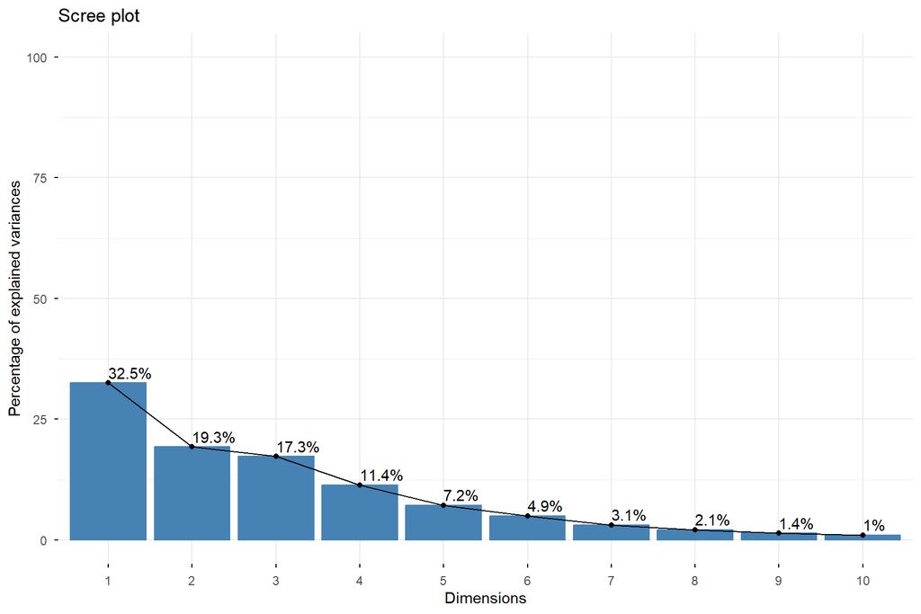

```r
fviz_eig(res_pca, addlabels = TRUE, ylim = c(0, 100))
```

Les résultats à commenter dans la soutenance sont:

- la part de variance expliquée par les premiers axes,
- les variables qui construisent principalement l’axe 1 et l’axe 2,
- les contributions des variables aux dimensions,
- la proximité entre observations semblables sur le plan factoriel.

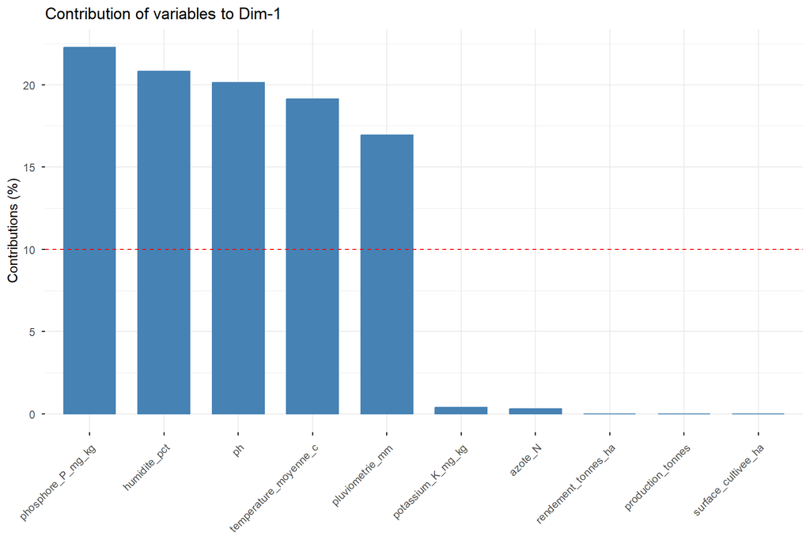

```r
fviz_contrib(res_pca, choice = "var", axes = 1, top = 10)
```

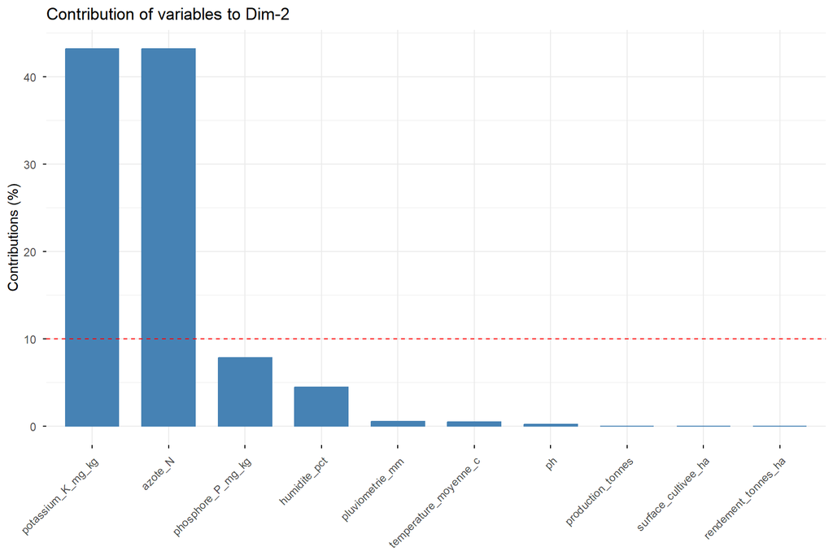

```r
fviz_contrib(res_pca, choice = "var", axes = 2, top = 10)
```

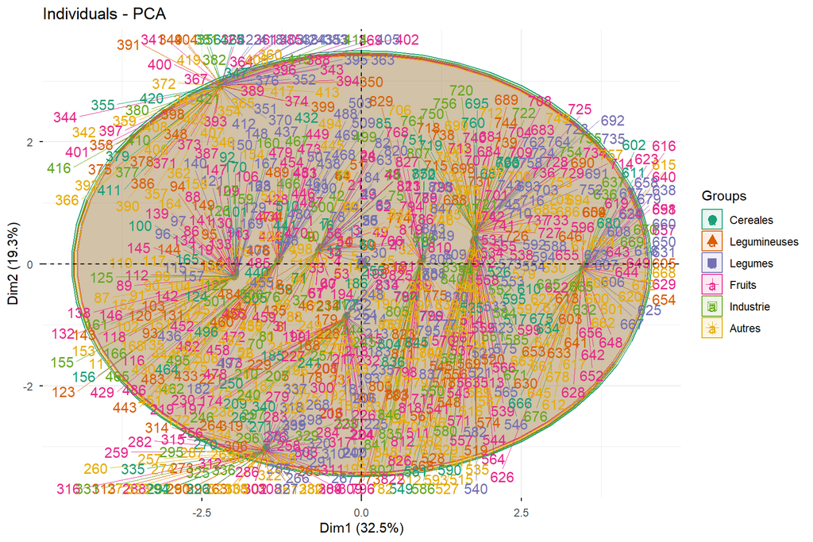

```r
fviz_pca_ind(
  res_pca,
  repel = TRUE,
  habillage = df_model$famille_culture,
  addEllipses = TRUE,
  palette = "Dark2"
)
```

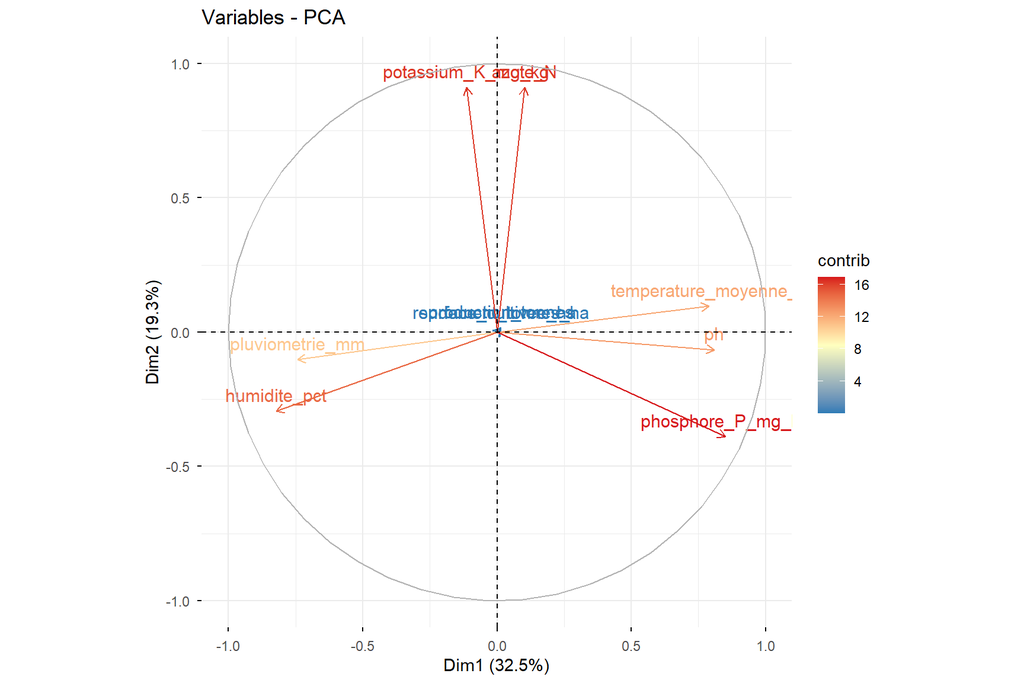

```r
fviz_pca_var(res_pca, col.var = "contrib", gradient.cols = c("#2c7bb6", "#ffffbf", "#d7191c"))
```

# 4 4. Classification obligatoire: K-means et CAH

La segmentation est réalisée sur les coordonnées factorielles de l’ACP. Ce choix réduit la redondance des variables et améliore la stabilité des classes. K-means est utilisé comme segmentation principale, tandis que la CAH sert de contrôle de cohérence.

```r
pca_scores <- as.data.frame(res_pca$ind$coord[, 1:3, drop = FALSE])
colnames(pca_scores) <- c("Dim1", "Dim2", "Dim3")

set.seed(42)
```

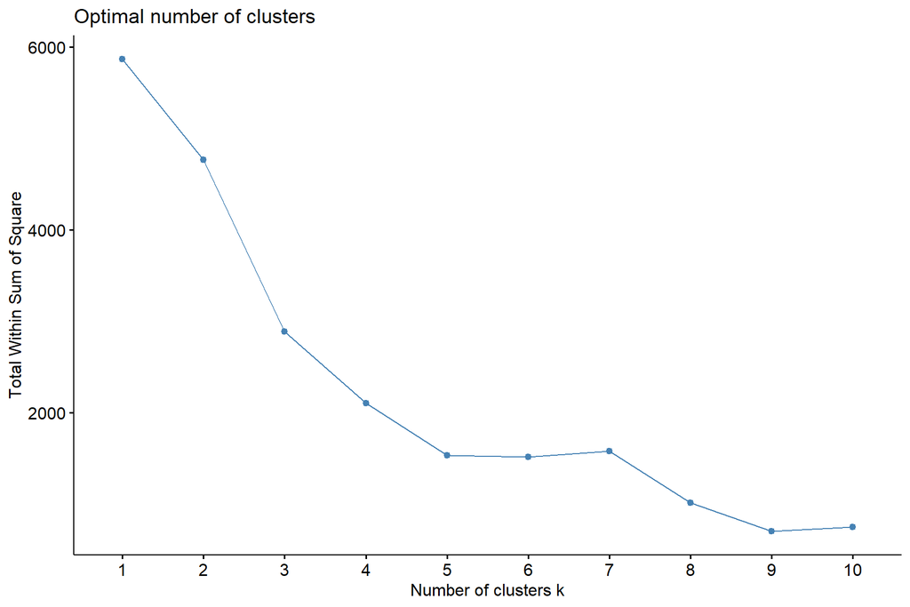

```r
fviz_nbclust(pca_scores, kmeans, method = "wss")
```

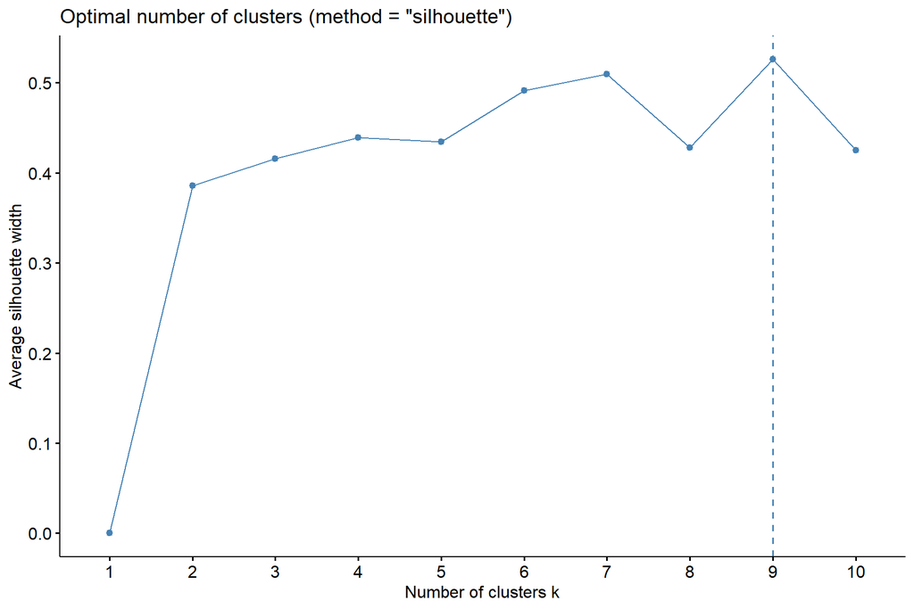

```r
fviz_nbclust(pca_scores, kmeans, method = "silhouette")
```

```r
k_final <- 3
km_res <- kmeans(pca_scores, centers = k_final, nstart = 50)
df_model$cluster_km <- factor(km_res$cluster)

km_res$centers
```

```
##        Dim1       Dim2         Dim3
## 1 -2.208240  2.9289033 -0.022062271
## 2  1.985351  0.2279545 -0.008274839
## 3 -1.146633 -0.7681443  0.011032325
```

```r
profil_km <- df_model %>%
  mutate(cluster_km = factor(km_res$cluster)) %>%
  group_by(cluster_km) %>%
  summarise(
    n = n(),
    across(all_of(numeric_vars), ~ mean(.x, na.rm = TRUE)),
    .groups = "drop"
  )

profil_km
```

```
## # A tibble: 3 × 12
##   cluster_km     n surface_cultivee_ha production_tonnes rendement_tonnes_ha
##   <fct>      <int>               <dbl>             <dbl>               <dbl>
## 1 1             85              13245.            90534.               0.905
## 2 2            340              13241.            91053.               0.910
## 3 3            425              13181.            88885.               0.885
## # ℹ 7 more variables: pluviometrie_mm <dbl>, temperature_moyenne_c <dbl>,
## #   humidite_pct <dbl>, ph <dbl>, azote_N <dbl>, phosphore_P_mg_kg <dbl>,
## #   potassium_K_mg_kg <dbl>
```

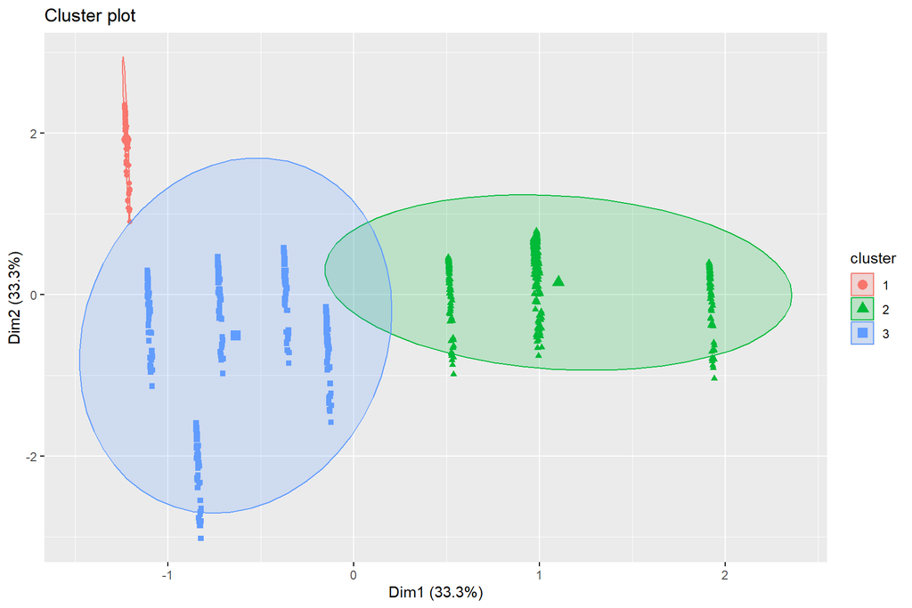

```r
fviz_cluster(km_res, data = pca_scores, geom = "point", ellipse.type = "norm")
```

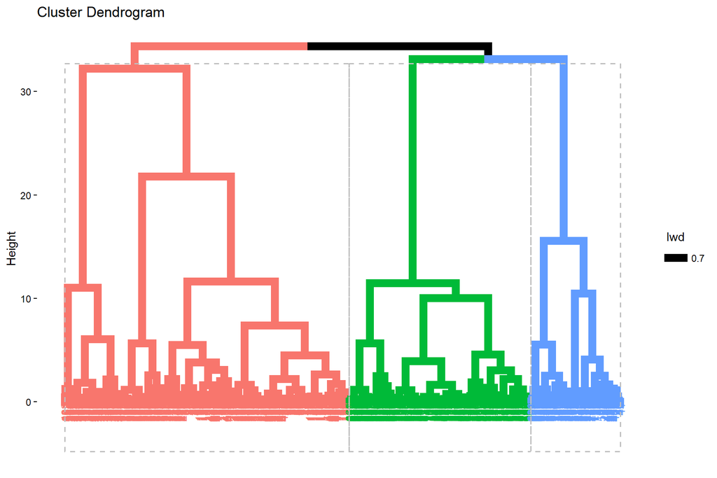

```r
cah_dist <- dist(scale(pca_scores))
cah_res <- hclust(cah_dist, method = "ward.D2")

fviz_dend(cah_res, k = k_final, rect = TRUE, cex = 0.7)
```

```r
df_model$cluster_cah <- factor(cutree(cah_res, k = k_final))
```

La CAH permet de vérifier si la structure hiérarchique est compatible avec le découpage de K-means. Si les groupes se recouvrent peu et restent cohérents sur le plan factoriel, la typologie est considérée comme stable.

# 5 5. Analyse combinée: lien ACP - segmentation

L’intérêt principal est de montrer que les clusters ne sont pas arbitraires: ils occupent des zones distinctes de l’espace factoriel.

```r
# Créer le dataframe clustérisé en ajoutant directement les clusters et scores PCA
df_clustered <- df_model %>%
  mutate(
    Dim1 = pca_scores$Dim1,
    Dim2 = pca_scores$Dim2,
    Dim3 = pca_scores$Dim3,
    cluster_km = factor(km_res$cluster),
    cluster_cah = factor(cutree(cah_res, k = k_final))
  )

cluster_pca_summary <- df_clustered %>%
  group_by(cluster_km) %>%
  summarise(
    across(c(Dim1, Dim2, Dim3), mean),
    .groups = "drop"
  )

cluster_profile <- df_clustered %>%
  group_by(cluster_km) %>%
  summarise(
    n = n(),
    part_fruits = mean(famille_culture == "Fruits"),
    part_cereales = mean(famille_culture == "Cereales"),
    part_legumes = mean(famille_culture == "Legumes"),
    rendement_moyen = mean(rendement_tonnes_ha),
    pluie_moyenne = mean(pluviometrie_mm),
    temperature_moyenne = mean(temperature_moyenne_c),
    humidite_moyenne = mean(humidite_pct),
    .groups = "drop"
  )

cluster_pca_summary
```

```
## # A tibble: 3 × 4
##   cluster_km  Dim1   Dim2     Dim3
##   <fct>      <dbl>  <dbl>    <dbl>
## 1 1          -2.21  2.93  -0.0221
## 2 2           1.99  0.228 -0.00827
## 3 3          -1.15 -0.768  0.0110
```

```r
cluster_profile
```

```
## # A tibble: 3 × 9
##   cluster_km     n part_fruits part_cereales part_legumes rendement_moyen
##   <fct>      <int>       <dbl>         <dbl>        <dbl>           <dbl>
## 1 1             85       0.259        0.0824        0.176           0.905
## 2 2            340       0.259        0.0824        0.176           0.910
## 3 3            425       0.259        0.0824        0.176           0.885
## # ℹ 3 more variables: pluie_moyenne <dbl>, temperature_moyenne <dbl>,
## #   humidite_moyenne <dbl>
```

```r
table(df_clustered$cluster_km, df_clustered$cluster_cah)
```

```
##
##       1   2   3
##   1  85   0   0
##   2   0  62 278
##   3 350  75   0
```

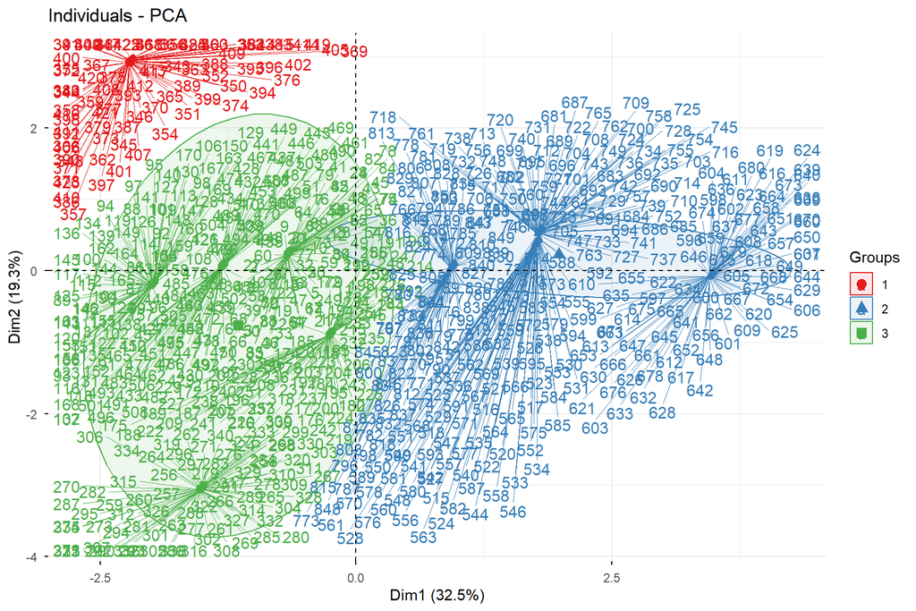

```r
fviz_pca_ind(
  res_pca,
  repel = TRUE,
  habillage = df_clustered$cluster_km,
  addEllipses = TRUE,
  palette = "Set1"
)
```

# 6 6. Interprétation et conclusions décisionnelles

L’interprétation doit relier les axes factoriels aux clusters:

Dans une soutenance, il faut commenter les résultats comme suit:

1. Décrire le sens de l’axe 1 et de l’axe 2 à partir des contributions des variables.
2. Relier chaque cluster à des variables dominantes: rendement, pluie, température, humidité, pH, N, P, K.
3. Expliquer quels profils sont les plus favorables à une action de conseil agricole.
4. Montrer l’intérêt métier: mieux cibler les cultures, ajuster les intrants, prioriser les zones à risque et optimiser l’allocation des ressources.

## 6.1 Conclusion synthétique

Cette version du projet remplit les exigences du mini-projet multivarié:

- préparation des données avec justification méthodologique,
- ACP pour réduire la dimension et interpréter la structure,
- K-means et CAH pour construire et valider une typologie,
- lecture métier des profils obtenus pour guider la décision.

Le fichier source à exécuter ou à rendre est ce document RMarkdown. Il peut être knitté en HTML pour produire un rapport de soutenance.